# Case Study 2

Ikenna Nwaogu

12/3/2019

## Executive Summary

Employment attrition and how it relates to other variables from a dataset provided by DDS Analytics was analyzed in the first part of this case study. We have also analyzed how these variables relate to the monthly income. We specifically looked at variables like, Job Role, Job Satisfaction, Stock Options, Marital Status and so on in other to predict the outcome of Attrition. We also used the above variables like Attrition, Job Level, Years At Company, Years In Current Role etc to predict the outcome of Monthly income.

we used cross validation to split our dataset to train and test our model. we split the data 90% train and 10% test. This was done because of the nature of our dataset and because we have enough test datset to validate our trained model.

## Introduction

DDSAnalytics is an analytics company that specializes in talent management solutions for Fortune 100 companies. Talent management is defined as the iterative process of developing and retaining employees. It may include workforce planning, employee training programs, identifying high-potential employees and reducing/preventing voluntary employee turnover (attrition). To gain a competitive edge over its competition, DDSAnalytics is planning to leverage data science for talent management. The executive leadership has identified predicting employee turnover as its first application of data science for talent management. We are tasked to conduct an analysis of existing employee data.

## 1. Classification

```r
#install.packages("Boruta")
library(caret)
library(e1071)
library(dplyr)
library(tidyverse)
library(tidyr)
library(Boruta)

CaseStudy2_data <- read.csv("data/CaseStudy2-data.csv", header = TRUE)
names(CaseStudy2_data)
```

```
##  [1] "ID"                       "Age"
##  [3] "Attrition"                "BusinessTravel"
##  [5] "DailyRate"                "Department"
##  [7] "DistanceFromHome"         "Education"
##  [9] "EducationField"           "EmployeeCount"
## [11] "EmployeeNumber"           "EnvironmentSatisfaction"
## [13] "Gender"                   "HourlyRate"
## [15] "JobInvolvement"           "JobLevel"
## [17] "JobRole"                  "JobSatisfaction"
## [19] "MaritalStatus"            "MonthlyIncome"
## [21] "MonthlyRate"              "NumCompaniesWorked"
## [23] "Over18"                   "OverTime"
## [25] "PercentSalaryHike"        "PerformanceRating"
## [27] "RelationshipSatisfaction" "StandardHours"
## [29] "StockOptionLevel"         "TotalWorkingYears"
## [31] "TrainingTimesLastYear"    "WorkLifeBalance"
## [33] "YearsAtCompany"           "YearsInCurrentRole"
## [35] "YearsSinceLastPromotion"  "YearsWithCurrManager"
```

#### Using the Boruta package we continue by making use of the feature selection to give us an idea on which features are more important.

```r
# Decide if a variable is important or not using Boruta
boruta_output <- Boruta(Attrition ~ ., data=CaseStudy2_data, doTrace=2)
boruta_signif <- names(boruta_output$finalDecision[boruta_output$finalDecision %in% c("Confirmed", "Tentative")])  # collect Confirmed and Tentative variables
print(boruta_signif)  # significant variables
```

```
##  [1] "Age"                  "Department"           "JobInvolvement"
##  [4] "JobLevel"             "JobRole"              "JobSatisfaction"
##  [7] "MaritalStatus"        "MonthlyIncome"        "NumCompaniesWorked"
## [10] "OverTime"             "StockOptionLevel"     "TotalWorkingYears"
## [13] "WorkLifeBalance"      "YearsAtCompany"       "YearsInCurrentRole"
## [16] "YearsWithCurrManager"
```

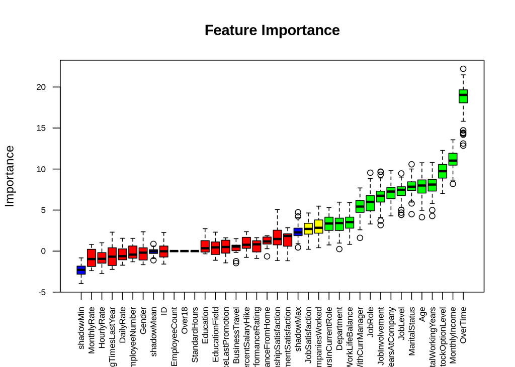

```r
plot(boruta_output, cex.axis=.7, las=2, xlab="", main="Feature Importance")
```

#### Exploratory Data Analysis

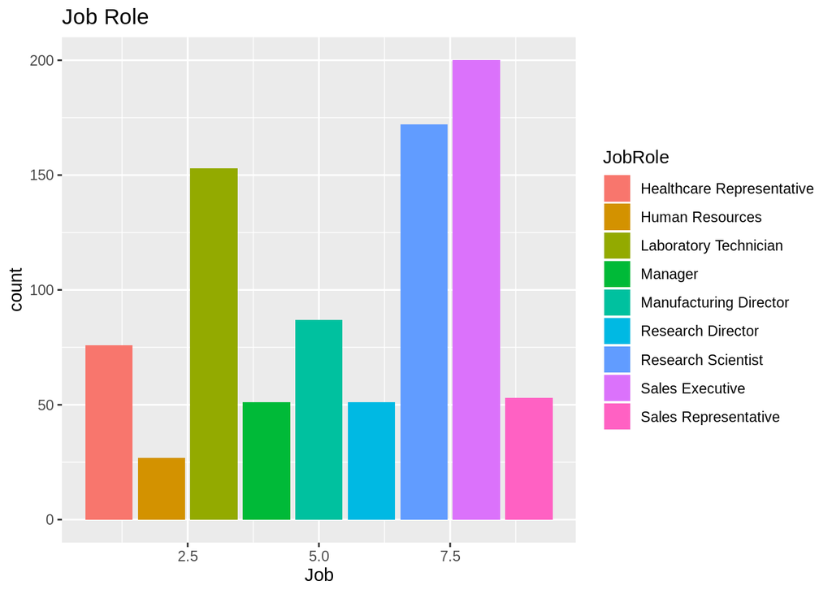

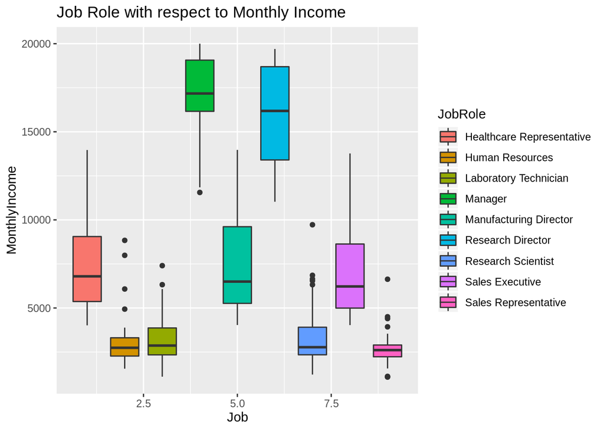

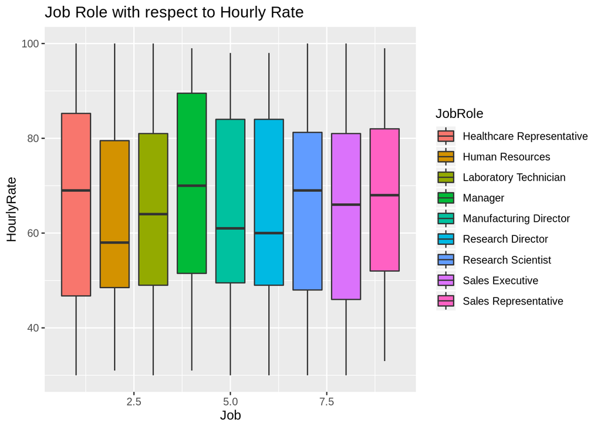

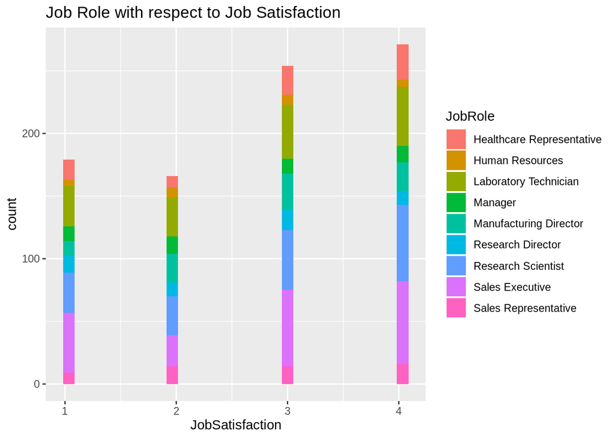

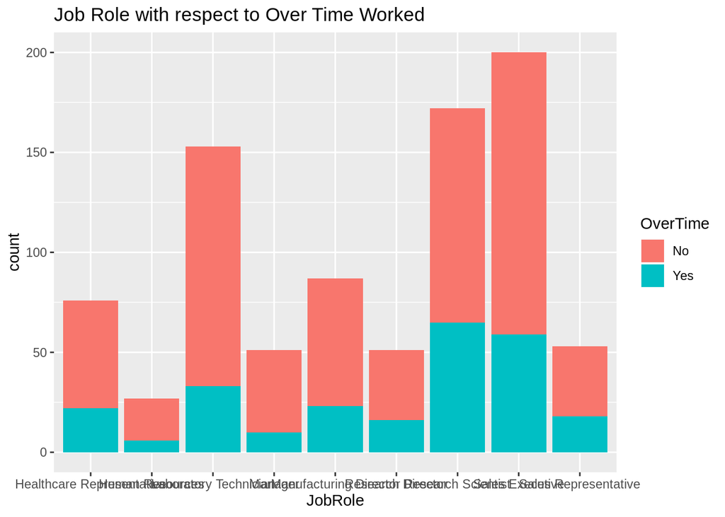

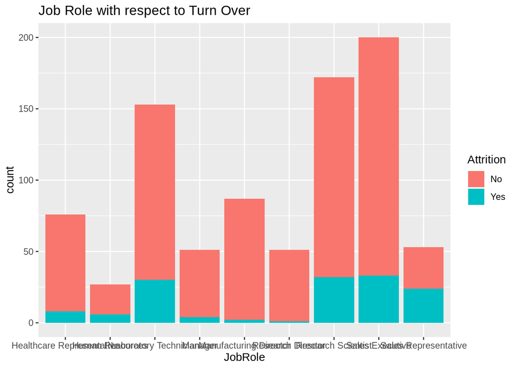

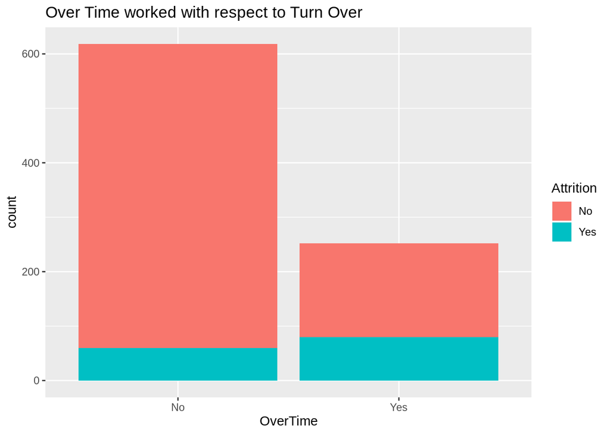

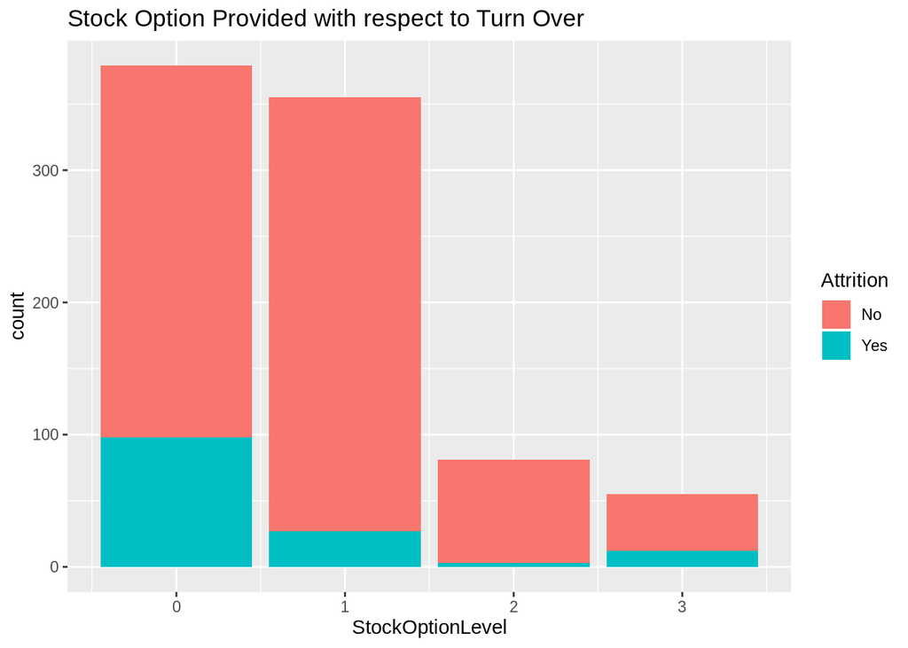

We can clearly see above that there are relationships between jobe role and many other variables.

### Data Cleaning and Type Conversion

This section we clean the data and convert some of the data types to the relevant datatypes for our prediction analysis. We also scaled the numeric columns to get a better scaling for our model.

```
##       Age          Dept       OverTime    MonthlyIncome
##  Min.   :-2.1094   1: 35   Min.   :1.00   Min.   :-1.1548
##  1st Qu.:-0.7650   2:562   1st Qu.:1.00   1st Qu.:-0.7723
##  Median :-0.2049   3:273   Median :1.00   Median :-0.3142
##  Mean   : 0.0000           Mean   :1.29   Mean   : 0.0000
##  3rd Qu.: 0.6914           3rd Qu.:2.00   3rd Qu.: 0.3897
##  Max.   : 2.5959           Max.   :2.00   Max.   : 2.9599
##
##  StockOptionLevel Stat         Job      YearsInCurrentRole    Gender
##  0:379            1:191   8      :200   Min.   :0.000      Female:354
##  1:355            2:410   7      :172   1st Qu.:1.414      Male  :516
##  2: 81            3:269   3      :153   Median :1.732
##  3: 55                    5      : 87   Mean   :1.761
##                           1      : 76   3rd Qu.:2.646
##                           9      : 53   Max.   :4.243
##                           (Other):129
##  YearsWithCurrManager.V1 JobInvolvement  YearsAtCompany.V1
##  Min.   :-1.158287       1: 47          Min.   :-1.156291
##  1st Qu.:-0.598759       2:228          1st Qu.:-0.658038
##  Median :-0.318995       3:514          Median :-0.325869
##  Mean   : 0.000000       4: 81          Mean   : 0.000000
##  3rd Qu.: 0.800061                      3rd Qu.: 0.504553
##  Max.   : 3.597701                      Max.   : 5.487084
##
##  TotalWorkingYears.V1 NumCompaniesWorked.V1 JobSatisfaction
##  Min.   :-1.471036    Min.   :-1.0821852    1:179
##  1st Qu.:-0.672491    1st Qu.:-0.6854296    2:166
##  Median :-0.140128    Median :-0.2886739    3:254
##  Mean   : 0.000000    Mean   : 0.0000000    4:271
##  3rd Qu.: 0.525326    3rd Qu.: 0.5048374
##  Max.   : 3.852596    Max.   : 2.4886156
##
##  WorkLifeBalance Attrition
##  1: 48           No :730
##  2:192           Yes:140
##  3:532
##  4: 98
##
##
##
```

#### Naive Bayes Model

Above are the summary of dataset used which features all the variables that would be used to train the model. We will use naive bayes model for our prediction model using the relevant features. We also applied 90% to 10% train and test split. Due to nature of the dataset we needed more data to train and that is the reason why the split was done with this ratio. We also used a seed of 10 for the split.

```
##      predict
##       No Yes
##   No  61   9
##   Yes  6  11
```

```
##  Accuracy
## 0.8275862
```

```
## Sensitivity
##   0.8714286
```

```
## Specificity
##   0.6470588
```

We see above that we get a very low readings especially for specificity. We reached the goal of a Specifity of 0.6 but our sensitivity and Accuracy are a bit low.

#### Seed Iteration

Now we try to loop through 1-150 seeds to gain a better accuracy, sensitivity, specificity combination reading.

```
##   ID  Accuracy Sensitivity Specificity
## 1 20 0.9195402   0.9615385   0.5555556
## 2 76 0.9195402   0.9493671   0.6250000
```

```
##    ID Accuracy Sensitivity Specificity
## 1 148 0.908046   0.9861111   0.5333333
```

```
##   ID Accuracy Sensitivity Specificity
## 1 88 0.908046         0.9           1
```

```
##   ID  Accuracy Sensitivity Specificity
## 1 36 0.7356322   0.8358209         0.4
```

```
##    ID  Accuracy Sensitivity Specificity
## 1 141 0.7471264   0.7631579   0.6363636
```

```
##   ID  Accuracy Sensitivity Specificity
## 1 31 0.8045977   0.9054054   0.2307692
```

```
## [1] 0.8409195
```

```
## [1] 0.8901336
```

```
## [1] 0.5843208
```

## 2. Regression

```r
# Decide if a variable is important or not using Boruta
boruta_output <- Boruta(MonthlyIncome ~ ., data=CaseStudy2_data, doTrace=2)
boruta_signif <- names(boruta_output$finalDecision[boruta_output$finalDecision %in% c("Confirmed", "Tentative")])  # collect Confirmed and Tentative variables
print(boruta_signif)  # significant variables
```

```
##  [1] "Age"                     "Attrition"
##  [3] "Department"              "Education"
##  [5] "JobLevel"                "JobRole"
##  [7] "NumCompaniesWorked"      "TotalWorkingYears"
##  [9] "YearsAtCompany"          "YearsInCurrentRole"
## [11] "YearsSinceLastPromotion" "YearsWithCurrManager"
## [13] "Job"                     "Dept"
```

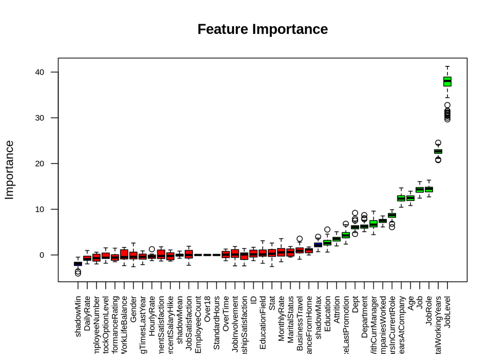

```r
plot(boruta_output, cex.axis=.7, las=2, xlab="", main="Feature Importance")
```

#### Summary of the feature selected

```
##       Age                  BusinessTravel Dept         Job
##  Min.   :18.00   Non-Travel       : 94    1: 35   8      :200
##  1st Qu.:30.00   Travel_Frequently:158    2:562   7      :172
##  Median :35.00   Travel_Rarely    :618    3:273   3      :153
##  Mean   :36.83                                    5      : 87
##  3rd Qu.:43.00                                    1      : 76
##  Max.   :60.00                                    9      : 53
##                                                   (Other):129
##  YearsInCurrentRole YearsWithCurrManager JobInvolvement YearsAtCompany
##  Min.   : 0.000     Min.   : 0.00        1: 47          Min.   : 0.000
##  1st Qu.: 2.000     1st Qu.: 2.00        2:228          1st Qu.: 3.000
##  Median : 3.000     Median : 3.00        3:514          Median : 5.000
##  Mean   : 4.205     Mean   : 4.14        4: 81          Mean   : 6.962
##  3rd Qu.: 7.000     3rd Qu.: 7.00                       3rd Qu.:10.000
##  Max.   :18.000     Max.   :17.00                       Max.   :40.000
##
##  TotalWorkingYears NumCompaniesWorked JobSatisfaction WorkLifeBalance
##  Min.   : 0.00     Min.   :0.000      Min.   :1.000   Min.   :1.000
##  1st Qu.: 6.00     1st Qu.:1.000      1st Qu.:2.000   1st Qu.:2.000
##  Median :10.00     Median :2.000      Median :3.000   Median :3.000
##  Mean   :11.05     Mean   :2.728      Mean   :2.709   Mean   :2.782
##  3rd Qu.:15.00     3rd Qu.:4.000      3rd Qu.:4.000   3rd Qu.:3.000
##  Max.   :40.00     Max.   :9.000      Max.   :4.000   Max.   :4.000
##
##     JobLevel     YearsSinceLastPromotion Education Attrition
##  Min.   :1.000   Min.   : 0.000          1: 98     No :730
##  1st Qu.:1.000   1st Qu.: 0.000          2:182     Yes:140
##  Median :2.000   Median : 1.000          3:324
##  Mean   :2.039   Mean   : 2.169          4:240
##  3rd Qu.:3.000   3rd Qu.: 3.000          5: 26
##  Max.   :5.000   Max.   :15.000
##
##  MonthlyIncome
##  Min.   : 1081
##  1st Qu.: 2840
##  Median : 4946
##  Mean   : 6390
##  3rd Qu.: 8182
##  Max.   :19999
##
```

#### Regression Model

Now we loop through 150 iterations of seed to get one with a lower RMSE. We also used 90% train and 10% test splits of the dataset. We achieved the lowest RMSE = 841 at seed 12 and the highest RMSE = 1384 at seed 69 with an avgerage RMSE of 1054.

```
##   ID     RMSE
## 1 69 1384.699
```

```
##   ID     RMSE
## 1 12 841.5344
```

```
## [1] 1054.068
```

## Conclusion

In conclusion, we analyzed at dataset for employment attrition and how it relates to other variables in the dataset; we have also analyzed how these variables relate to the monthly income. We specifically looked at variables like, Job Role, Job Satisfaction, Stock Options, Marital Status and so on in other to predict the outcome of Attrition. We also used the above variables like Attrition, Job Level, Years At Company, Years In Current Role etc to predict the outcome of Monthly income.

### Youtube Presentation link

https://youtu.be/CM2GDRPQfOA